# *Please see the below instructions for the final group project:*

# Examine Feature Importance after SMOTE balancing results

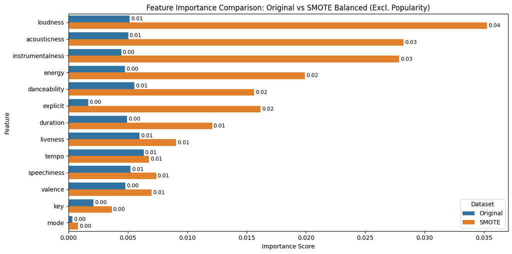

```python
# === STEP 1: Original Train Set ===
X_orig = train_df.drop(columns=['popularity_label'])
y_orig = train_df['popularity_label']

rf_orig = RandomForestClassifier(n_estimators=50, random_state=42)
rf_orig.fit(X_orig, y_orig)

import_orig = pd.DataFrame({
    'Feature': X_orig.columns,
    'Importance': rf_orig.feature_importances_,
    'Set': 'Original'
})

# === STEP 2: SMOTE-Balanced Train Set ===
X_bal = train_df_balanced.drop(columns=['popularity_label'])
y_bal = train_df_balanced['popularity_label']

rf_bal = RandomForestClassifier(n_estimators=50, random_state=42)
rf_bal.fit(X_bal, y_bal)

import_bal = pd.DataFrame({
    'Feature': X_bal.columns,
    'Importance': rf_bal.feature_importances_,
    'Set': 'SMOTE'
})

# === STEP 3: Combine and Remove 'popularity' Feature ===
importances = pd.concat([import_orig, import_bal])
importances = importances[importances['Feature'] != 'popularity']  # REMOVE popularity

# Sort features by total importance across both sets
feature_order = (importances
                 .groupby('Feature')['Importance']
                 .sum()
                 .sort_values(ascending=False)
                 .index)

# === Plot ===
plt.figure(figsize=(12, 6))
ax = sns.barplot(data=importances, x='Importance', y='Feature', hue='Set', dodge=True, order=feature_order)
plt.title('Feature Importance Comparison: Original vs SMOTE Balanced (Excl. Popularity)')
plt.xlabel('Importance Score')
plt.ylabel('Feature')
plt.legend(title='Dataset')

# Add value labels
for container in ax.containers:
    ax.bar_label(container, fmt="%.2f", label_type='edge', padding=2, fontsize=9)

plt.tight_layout()
plt.show()
```

In the original dataset, most features had very low importance, indicating that the model was likely overfitting to a small subset of the data or was biased due to class imbalance. After applying SMOTE, the importance scores became more meaningful and better distributed across several features.

Notably, features like loudness, acousticness, instrumentalness, energy, and danceability showed a significant increase in importance after balancing, suggesting that the model trained on the SMOTE dataset is leveraging a more diverse and relevant set of audio characteristics.

This demonstrates that SMOTE balancing improves model robustness by reducing overreliance on any single feature and encouraging the use of a broader, more informative feature set.

# Correlation Heatmap after SMOTE balancing of the Data

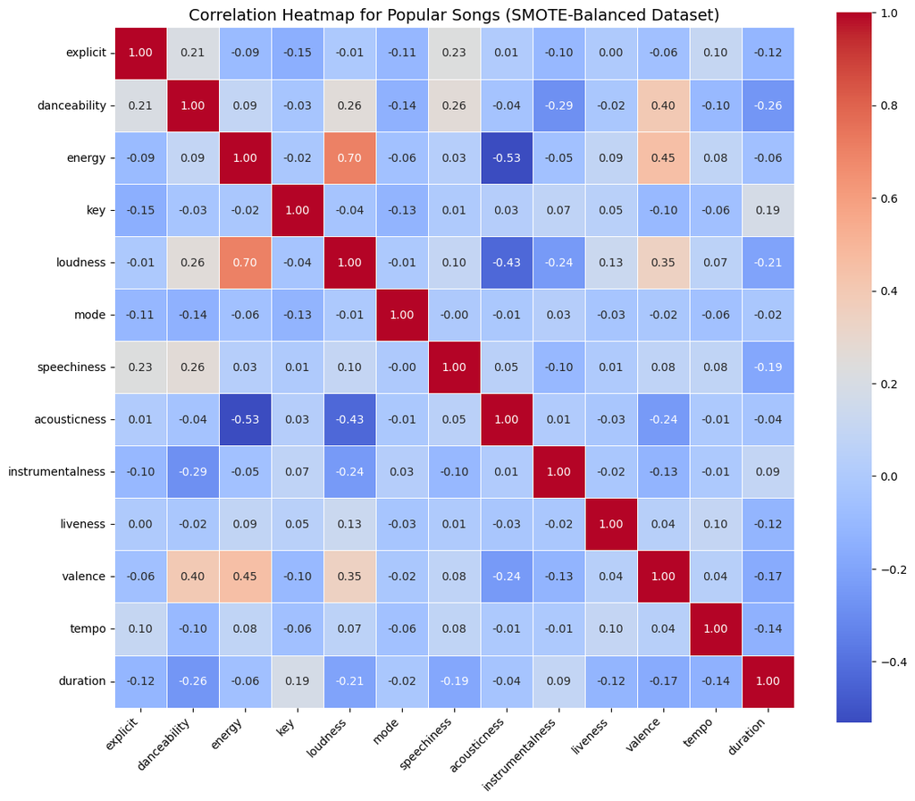

```python
# Filter SMOTE-balanced dataset to only popular songs
popular_df = train_df_balanced[train_df_balanced['popularity_label'] == 1]

# Drop target and any form of 'popularity' if present
features_to_exclude = ['popularity_label', 'popularity']
feature_cols = [col for col in popular_df.columns if col not in features_to_exclude]

# Compute correlation matrix
corr_matrix = popular_df[feature_cols].corr()

# Plot the heatmap
plt.figure(figsize=(12, 10))
sns.heatmap(corr_matrix, annot=True, fmt=".2f", cmap='coolwarm', square=True, linewidths=0.5)

# Add title and format
plt.title('Correlation Heatmap for Popular Songs (SMOTE-Balanced Dataset)', fontsize=14)
plt.xticks(rotation=45, ha='right')
plt.yticks(rotation=0)
plt.tight_layout()
plt.show()
```

# Selection of features to best predict a songs possibility of popularity

1. `danceability`: Indicates how suitable a song is for dancing; higher values often align with mainstream, upbeat tracks that tend to be more popular.
2. `energy`: Reflects the intensity and activity of a track; energetic songs are typically more engaging and radio-friendly.
3. `loudness`: Measures overall volume; louder songs often feel more polished or produced, which is common in popular music.
4. `speechiness`: Captures the presence of spoken words; moderate values can suggest genres like rap or pop that resonate with broad audiences.
5. `acousticness`: Represents the likelihood a song is acoustic; lower values are common in modern, heavily produced hits, making it useful for distinguishing popular from niche acoustic tracks.

`acousticness`, though slightly negatively correlated, adds complementary contrast in genre differentiation, helping models generalize across song types.

```python
# Use selected features and balanced data
selected_features = ['danceability', 'energy', 'loudness', 'speechiness','acousticness']
X_train = train_df_balanced[selected_features]
y_train = train_df_balanced['popularity_label']
X_test = test_df[selected_features]
y_test = test_df['popularity_label']

# Scale features
scaler = StandardScaler()
X_train_scaled = scaler.fit_transform(X_train)
X_test_scaled = scaler.transform(X_test)
```

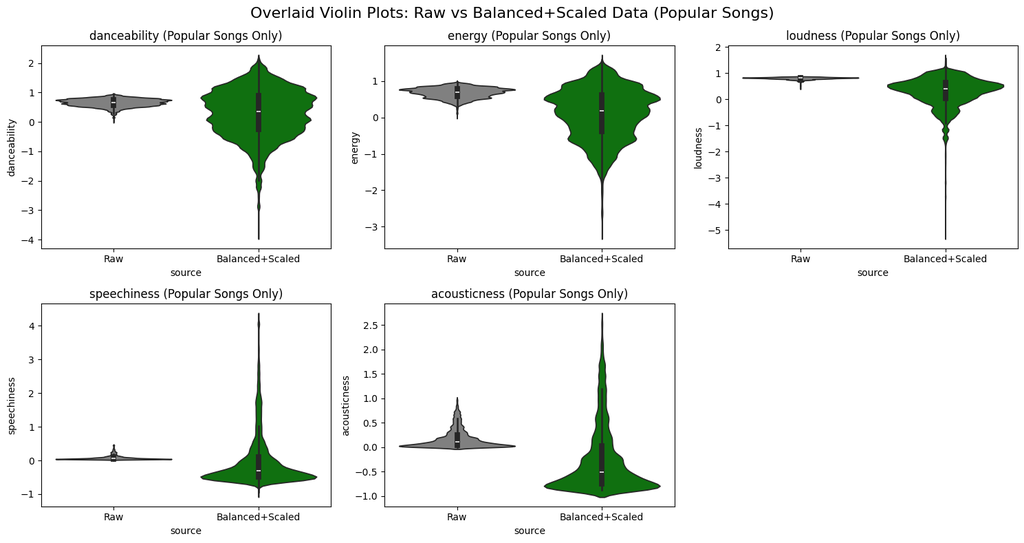

```python
# --- Raw Dataset ---
raw_df = train_df_balanced[selected_features + ['popularity_label']].copy()
raw_df['source'] = 'Raw'

# --- Scaled Balanced Dataset ---
scaled_df = pd.DataFrame(X_train_scaled, columns=selected_features)
scaled_df['popularity_label'] = y_train.values
scaled_df['source'] = 'Balanced+Scaled'

# --- Combine for Plotting ---
combined_df = pd.concat([raw_df, scaled_df], ignore_index=True)

# Plot overlaid violin plots split by source
plt.figure(figsize=(15, 8))
for i, feature in enumerate(selected_features):
    plt.subplot(2, 3, i + 1)
    sns.violinplot(
        data=combined_df[combined_df['popularity_label'] == 1],
        x='source', y=feature,
        palette=['gray', 'green']
    )
    plt.title(f'{feature} (Popular Songs Only)')
plt.suptitle("Overlaid Violin Plots: Raw vs Balanced+Scaled Data (Popular Songs)", fontsize=16)
plt.tight_layout()
plt.show()
```

# Train & Validate simple Decision Tree model

```python
# Train decision tree
dt_model = DecisionTreeClassifier(random_state=42)
# Use y_resampled which is the balanced target variable
dt_model.fit(X_train_scaled, y_resampled) # Changed y_train to y_resampled

# Predict on the test data (X_test_scaled) instead of the training data (X_train_scaled)
y_pred = dt_model.predict(X_test_scaled)
y_pred_proba = dt_model.predict_proba(X_test_scaled)[:, 1]
```

# Evaluate

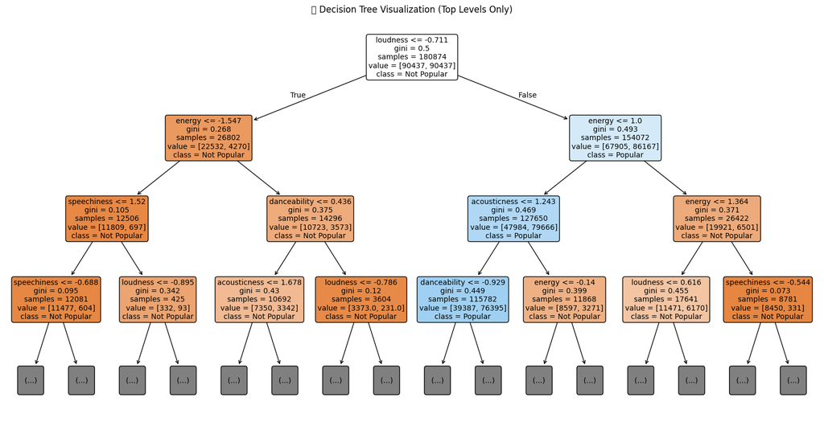

```python
# Optional: Assign feature names if known
feature_names = X_train.columns.tolist()  # Use this if X_train is a DataFrame
# Or hardcode if X_train_scaled is a NumPy array:
# feature_names = ['danceability', 'energy', 'loudness', 'speechiness', 'acousticness', ...]

# Plot full tree (or limit with max_depth=3 for simplicity)
plt.figure(figsize=(20, 10))
plot_tree(
    dt_model,
    feature_names=feature_names,
    class_names=['Not Popular', 'Popular'],
    filled=True,
    rounded=True,
    max_depth=3,  # Optional: to keep it readable
    fontsize=10
)
plt.title("🎋 Decision Tree Visualization (Top Levels Only)")
plt.show()
```

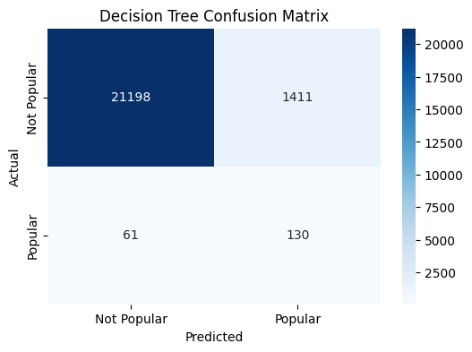

```python
cm = confusion_matrix(y_test, y_pred)
plt.figure(figsize=(6, 4))
sns.heatmap(cm, annot=True, fmt='d', cmap='Blues', xticklabels=['Not Popular', 'Popular'], yticklabels=['Not Popular', 'Popular'])
plt.xlabel('Predicted')
plt.ylabel('Actual')
plt.title('Decision Tree Confusion Matrix')
plt.show()
```

The decision tree model predicted 21,198 "Not Popular" songs correctly and 130 "Popular" songs correctly.

However, 1,411 "Not Popular" songs were misclassified as "Popular" (false positives), and 61 "Popular" songs were missed (false negatives).

While overall accuracy is strong, the model struggles more with distinguishing "Popular" songs, with a notable number of false positives. This trade-off may affect downstream tasks like recommendation or promotion strategies, where high precision for popularity is preferred.

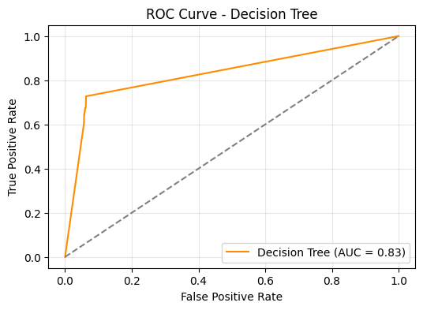

```
 Decision Tree Classification Report

              precision    recall  f1-score   support

           0       1.00      0.94      0.97     22609
           1       0.08      0.68      0.15       191

    accuracy                           0.94     22800
   macro avg       0.54      0.81      0.56     22800
weighted avg       0.99      0.94      0.96     22800
```

```python
# ROC curve and AUC
fpr, tpr, thresholds = roc_curve(y_test, y_pred_proba)
roc_auc = auc(fpr, tpr)

# Plot ROC curve
plt.figure(figsize=(6, 4))
plt.plot(fpr, tpr, label=f'Decision Tree (AUC = {roc_auc:.2f})', color='darkorange')
plt.plot([0, 1], [0, 1], linestyle='--', color='grey')
plt.xlabel('False Positive Rate')
plt.ylabel('True Positive Rate')
plt.title('ROC Curve - Decision Tree')
plt.legend(loc='lower right')
plt.grid(alpha=0.3)
plt.show()

#  DECISION TREE EVALUATION (Reuse existing classifier)
y_pred_tree = dt_model.predict(X_test_scaled)
tree_acc = accuracy_score(y_test, y_pred_tree)
tree_prec = precision_score(y_test, y_pred_tree)
tree_rec = recall_score(y_test, y_pred_tree)
tree_f1 = f1_score(y_test, y_pred_tree)

print(" Decision Tree Classification Report ")
print()
print(classification_report(y_test, y_pred_tree))
```

The Simple Decision Tree classifier evaluated on the SMOTE-balanced dataset shows improved sensitivity to the minority class (popular songs).

The ROC curve indicates an AUC score of 0.83, reflecting strong model discrimination between popular and non-popular songs.

These results suggest that SMOTE successfully enhances the model’s ability to detect popular songs, yet further tuning or ensemble methods may be needed to improve precision without sacrificing recall.

# Train & Validate simple DNN model on already split balanced

```python
# Define the DNN model
dnn_model = Sequential([
    Dense(16, activation='relu', input_shape=(X_train_scaled.shape[1],)),
    Dense(8, activation='relu'),
    Dense(1, activation='sigmoid')
])
# Compile the model
dnn_model.compile(
    loss='binary_crossentropy',
    optimizer='adam',
    metrics=['accuracy']
)
# Define early stopping
early_stop = EarlyStopping(
    monitor='val_loss',
    patience=3,
    min_delta=0.001,
    restore_best_weights=True
)
# Fit the model
history = dnn_model.fit(
    X_train_scaled, y_train,
    validation_split=0.2,
    epochs=30,
    batch_size=64,
    callbacks=[early_stop],
    verbose=1
)
# Predict probabilities for ROC
y_pred_dnn_probs = dnn_model.predict(X_test_scaled)
y_pred_dnn_labels = (y_pred_dnn_probs > 0.5).astype(int).flatten()
```

```
2261/2261 ━━━━━━━━━━━━━━━━━━━━ 107s 47ms/step - accuracy: 0.7115 - loss: 0.5540 - val_accuracy: 0.6258 - val_loss: 0.7355
2261/2261 ━━━━━━━━━━━━━━━━━━━━ 105s 47ms/step - accuracy: 0.7491 - loss: 0.4999 - val_accuracy: 0.6671 - val_loss: 0.6700
2261/2261 ━━━━━━━━━━━━━━━━━━━━ 109s 48ms/step - accuracy: 0.7509 - loss: 0.4895 - val_accuracy: 0.6105 - val_loss: 0.7348
2261/2261 ━━━━━━━━━━━━━━━━━━━━ 108s 48ms/step - accuracy: 0.7566 - loss: 0.4807 - val_accuracy: 0.6928 - val_loss: 0.6316
2261/2261 ━━━━━━━━━━━━━━━━━━━━ 107s 47ms/step - accuracy: 0.7641 - loss: 0.4730 - val_accuracy: 0.7141 - val_loss: 0.6166
2261/2261 ━━━━━━━━━━━━━━━━━━━━ 107s 47ms/step - accuracy: 0.7660 - loss: 0.4691 - val_accuracy: 0.7312 - val_loss: 0.5996
2261/2261 ━━━━━━━━━━━━━━━━━━━━ 108s 48ms/step - accuracy: 0.7711 - loss: 0.4641 - val_accuracy: 0.7551 - val_loss: 0.5668
2261/2261 ━━━━━━━━━━━━━━━━━━━━ 109s 48ms/step - accuracy: 0.7719 - loss: 0.4609 - val_accuracy: 0.6979 - val_loss: 0.6414
2261/2261 ━━━━━━━━━━━━━━━━━━━━ 108s 48ms/step - accuracy: 0.7727 - loss: 0.4585 - val_accuracy: 0.7079 - val_loss: 0.6283
2261/2261 ━━━━━━━━━━━━━━━━━━━━ 109s 48ms/step - accuracy: 0.7751 - loss: 0.4527 - val_accuracy: 0.6999 - val_loss: 0.6366
713/713 ━━━━━━━━━━━━━━━━━━━━ 3s 4ms/step
```

```
=== DNN Classification Report ===
              precision    recall  f1-score   support

           0       1.00      0.78      0.88     22609
           1       0.02      0.63      0.05       191

    accuracy                           0.78     22800
   macro avg       0.51      0.71      0.46     22800
weighted avg       0.99      0.78      0.87     22800
```

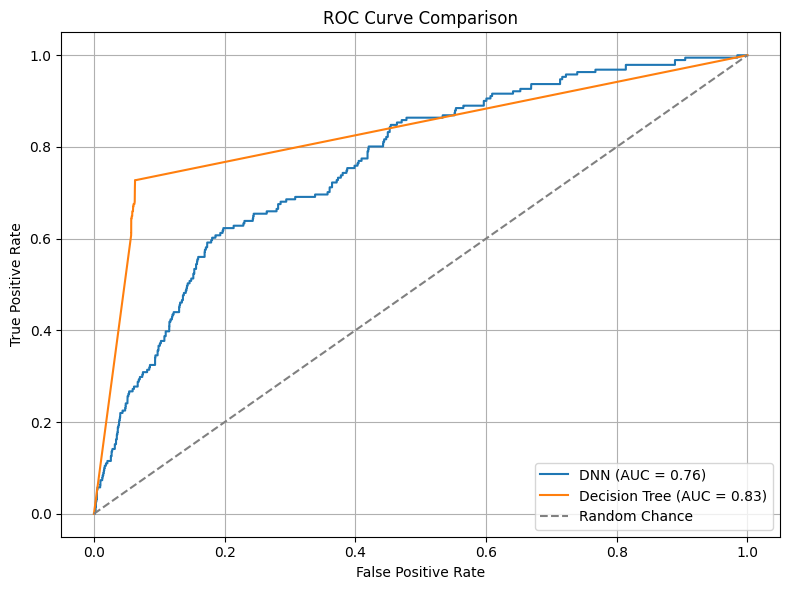

```python
# Metrics
dnn_acc = accuracy_score(y_test, y_pred_dnn_labels)
dnn_prec = precision_score(y_test, y_pred_dnn_labels)
dnn_rec = recall_score(y_test, y_pred_dnn_labels)
dnn_f1 = f1_score(y_test, y_pred_dnn_labels)

print("\n=== DNN Classification Report ===")
print(classification_report(y_test, y_pred_dnn_labels))

# ROC Curves
fpr_dnn, tpr_dnn, _ = roc_curve(y_test, y_pred_dnn_probs)
roc_auc_dnn = auc(fpr_dnn, tpr_dnn)
fpr_dt, tpr_dt, _ = roc_curve(y_test, y_pred_proba)
roc_auc_dt = auc(fpr_dt, tpr_dt)

# Plot ROC Curve Comparison
plt.figure(figsize=(8, 6))
plt.plot(fpr_dnn, tpr_dnn, label=f'DNN (AUC = {roc_auc_dnn:.2f})')
plt.plot(fpr_dt, tpr_dt, label=f'Decision Tree (AUC = {roc_auc_dt:.2f})')
plt.plot([0, 1], [0, 1], linestyle='--', color='gray', label='Random Chance')
plt.xlabel('False Positive Rate')
plt.ylabel('True Positive Rate')
plt.title('ROC Curve Comparison')
plt.legend(loc='lower right')
plt.grid(True)
plt.tight_layout()
plt.show()
```

[figure not shown]

```python
# Plot accuracy and loss over epochs
fig, ax = plt.subplots(1, 2, figsize=(14, 5))

# Accuracy
ax[0].plot(history.history['accuracy'], label='Train Accuracy')
ax[0].plot(history.history['val_accuracy'], label='Validation Accuracy')
ax[0].set_title('Model Accuracy Over Epochs')
ax[0].set_xlabel('Epoch')
ax[0].set_ylabel('Accuracy')
ax[0].legend()
ax[0].grid(True)

# Loss
ax[1].plot(history.history['loss'], label='Train Loss')
ax[1].plot(history.history['val_loss'], label='Validation Loss')
ax[1].set_title('Model Loss Over Epochs')
ax[1].set_xlabel('Epoch')
ax[1].set_ylabel('Loss')
ax[1].legend()
ax[1].grid(True)
plt.tight_layout()
plt.show()
```

[figure not shown]

```python
# Convert classification report to dataframe
report = classification_report(y_test, y_pred_dnn_labels, output_dict=True)
report_df = pd.DataFrame(report).transpose()

# Plot heatmap of classification report
plt.figure(figsize=(8, 5))
sns.heatmap(report_df.iloc[:-1, :-1], annot=True, cmap='YlGnBu')
plt.title("DNN Classification Report - Heatmap")
plt.show()
```

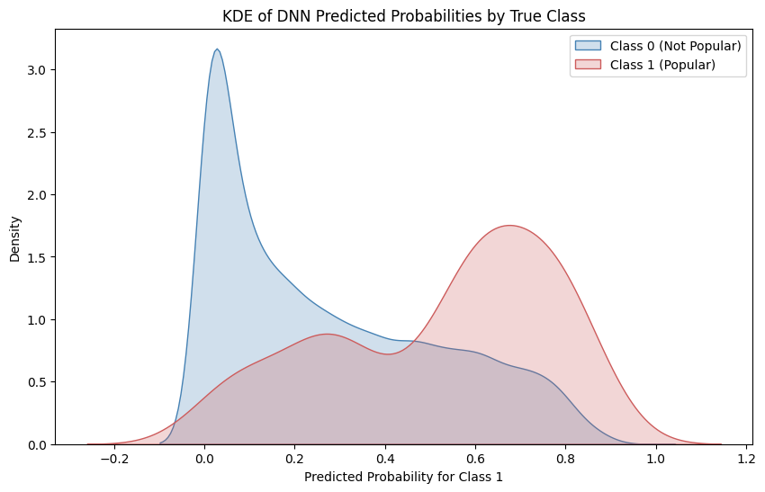

```python
# Since y_pred_dnn_probs is already (n_samples,) — probabilities for class 1
probs_class_1 = y_pred_dnn_probs.ravel()
plt.figure(figsize=(10, 6))

# Class 0 - Not Popular
sns.kdeplot(
    probs_class_1[y_test == 0],
    label='Class 0 (Not Popular)',
    fill=True,
    color='steelblue'
)
# Class 1 - Popular
sns.kdeplot(
    probs_class_1[y_test == 1],
    label='Class 1 (Popular)',
    fill=True,
    color='indianred'
)
plt.xlabel("Predicted Probability for Class 1")
plt.ylabel("Density")
plt.title("KDE of DNN Predicted Probabilities by True Class")
plt.legend()
plt.show()
```

This KDE plot visualizes predicted probabilities from the **DNN model**. Class 0 (Not Popular) is shown in blue and Class 1 (Popular) in red. DNN models output continuous probability scores, enabling this density comparison. If comparing to a Decision Tree, the distribution would be sharply split at 0 and 1, with no smooth curves.

[figure not shown]

```python
# === COMPARISON PLOT ===
labels = ['Accuracy', 'Precision', 'Recall', 'F1 Score']
tree_scores = [tree_acc, tree_prec, tree_rec, tree_f1]
dnn_scores = [dnn_acc, dnn_prec, dnn_rec, dnn_f1]

x = np.arange(len(labels))
width = 0.35

fig, ax = plt.subplots()
bars1 = ax.bar(x - width/2, tree_scores, width, label='Decision Tree')
bars2 = ax.bar(x + width/2, dnn_scores, width, label='DNN')

ax.set_ylabel('Scores')
ax.set_title('Model Comparison')
ax.set_xticks(x)
ax.set_xticklabels(labels)
ax.legend()
plt.ylim(0, 1.1)
plt.show()
```

[figure not shown]

```python
# === CONFUSION MATRICES ===
fig, axes = plt.subplots(1, 2, figsize=(12, 5))
sns.heatmap(confusion_matrix(y_test, y_pred_tree), annot=True, fmt='d', ax=axes[0], cmap='Blues')
axes[0].set_title("Decision Tree Confusion Matrix")
axes[0].set_xlabel("Predicted")
axes[0].set_ylabel("Actual")

sns.heatmap(confusion_matrix(y_test, y_pred_dnn_labels), annot=True, fmt='d', ax=axes[1], cmap='Greens')
axes[1].set_title("DNN Confusion Matrix")
axes[1].set_xlabel("Predicted")
axes[1].set_ylabel("Actual")
plt.tight_layout()
plt.show()
```

# Hypertuning Decision Tree with GridSearch Cross Validation

```python
# Create Decision Tree with class_weight balanced
dtree_tune = DecisionTreeClassifier(random_state=42, class_weight='balanced')

# Grid of hyperparameters
params = {
    'max_depth': [2, 3, 5, 10, 15, None],
    'min_samples_split': [2, 5, 10],
    'min_samples_leaf': [1, 2, 4],
    'criterion': ['gini', 'entropy']
}
# Define custom scoring metrics
scoring = {
    'roc_auc': 'roc_auc',
    'pr_auc': make_scorer(average_precision_score, needs_proba=True)
}
# Grid search using both scoring metrics
grid = GridSearchCV(dtree_tune, params, cv=5, scoring=scoring, refit='pr_auc', n_jobs=-1)
grid.fit(X_resampled, y_resampled)

# Best estimator and parameters
print("Best Parameters:", grid.best_params_)
```

```
Best Parameters: {'criterion': 'gini', 'max_depth': 2, 'min_samples_leaf': 1, 'min_samples_split': 2}
```

# Train & Evaluate tuned Decision Tree

```
 Tuned Decision Tree Classification Report
              precision    recall  f1-score   support

           0       1.00      0.47      0.64     22609
           1       0.01      0.87      0.03       191

    accuracy                           0.47     22800
   macro avg       0.51      0.67      0.33     22800
weighted avg       0.99      0.47      0.63     22800
```

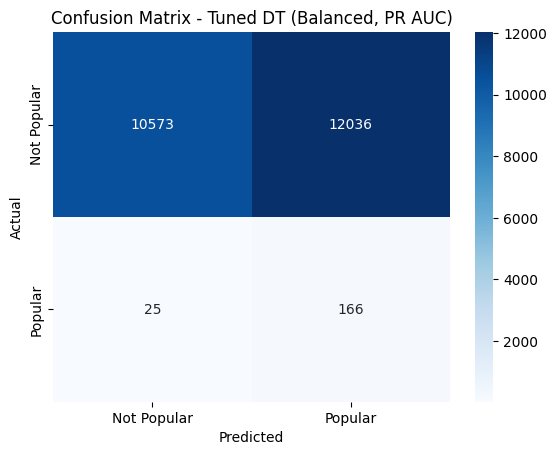

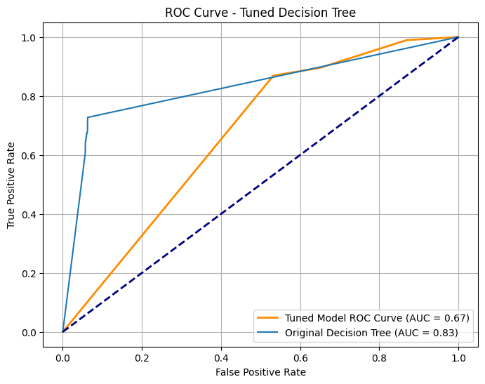

```python
#  Train the tuned Decision Tree
dt_tuned = DecisionTreeClassifier(
    random_state=42,
    class_weight='balanced',
    criterion='gini',
    max_depth=2,
    min_samples_leaf=1,
    min_samples_split=2
)
dt_tuned.fit(X_train_scaled, y_train)  # Use top features from permutation importance
y_pred_tuned = dt_tuned.predict(X_test_scaled)

#  Classification Report
print(" Tuned Decision Tree Classification Report ")
print(classification_report(y_test, y_pred_tuned))

#  Confusion Matrix
cmt = confusion_matrix(y_test, y_pred_tuned)
sns.heatmap(cmt, annot=True, fmt='d', cmap='Blues',
            xticklabels=['Not Popular', 'Popular'],
            yticklabels=['Not Popular', 'Popular'])
plt.title('Confusion Matrix - Tuned DT (Balanced, PR AUC)')
plt.xlabel('Predicted')
plt.ylabel('Actual')
plt.show()

#  ROC Curve
y_proba_tuned = dt_tuned.predict_proba(X_test_scaled)[:, 1]
fpr, tpr, _ = roc_curve(y_test, y_proba_tuned)
roc_auc = auc(fpr, tpr)

plt.figure(figsize=(8, 6))
plt.plot(fpr, tpr, color='darkorange', lw=2, label=f"Tuned Model ROC Curve (AUC = {roc_auc:.2f})")
plt.plot(fpr_dt, tpr_dt, label=f'Original Decision Tree (AUC = {roc_auc_dt:.2f})')
plt.plot([0, 1], [0, 1], color='navy', lw=2, linestyle='--')
plt.xlabel("False Positive Rate")
plt.ylabel("True Positive Rate")
plt.title("ROC Curve - Tuned Decision Tree")
plt.legend(loc="lower right")
plt.grid(True)
plt.show()
```

# Hypertuning DNN (manual hyperparameter tuning)

```python
# Minimal hyperparameter grid for testing
optimizers = {"adam": Adam()}           # Only 1 optimizer
neurons_list = [32]                     # Only 1 size
batch_sizes = [16]                      # Only 1 batch size
epochs_list = [5]                       # Fewer epochs

# Track the best result
best_acc = 0
best_model = None
best_params = {}

start_time = time.time()
```

```python
# Manual training loop
for opt_name, opt in optimizers.items():
    for neurons in neurons_list:
        for batch_size in batch_sizes:
            for epochs in epochs_list:
                print(f"\n Training: optimizer={opt_name}, neurons={neurons}, batch_size={batch_size}, epochs={epochs}")

                model = Sequential([
                    Dense(neurons, input_dim=X_train_scaled.shape[1], activation='relu'),
                    Dense(neurons // 2, activation='relu'),
                    Dense(1, activation='sigmoid') # Changed the output layer to a single neuron with sigmoid activation
                ])
                model.compile(optimizer=opt, loss='binary_crossentropy', metrics=['accuracy'])

                # Train the model
                history = model.fit(
                    X_train_scaled, y_train,
                    batch_size=batch_size,
                    epochs=epochs,
                    validation_split=0.2,
                    verbose=0
                )

                # Evaluate on test set
                y_pred = (model.predict(X_test_scaled, verbose=0) > 0.5).astype(int) # Predict probabilities and convert to binary labels
                acc = accuracy_score(y_test, y_pred)
                print(f"Accuracy: {acc:.4f}")

                # Save best model
                if acc > best_acc:
                    best_acc = acc
                    best_model = model
                    best_params = {
                        "optimizer": opt_name,
                        "neurons": neurons,
                        "batch_size": batch_size,
                        "epochs": epochs
                    }

print("\n Tuning complete")
print(f" Total time: {time.time() - start_time:.2f}s")
print(f" Best Accuracy: {best_acc:.4f}")
print(f" Best Params: {best_params}")
```

```
 Training: optimizer=adam, neurons=32, batch_size=16, epochs=5
Accuracy: 0.8214

 Tuning complete
 Total time: 2169.28s
 Best Accuracy: 0.8214
 Best Params: {'optimizer': 'adam', 'neurons': 32, 'batch_size': 16, 'epochs': 5}
```

```python
# Save the model to an HDF5 file
best_model.save('best_dnn_model.keras')
```

```python
# 1. Predict class labels from the best model
y_pred = np.argmax(best_model.predict(X_test_scaled, verbose=0), axis=1)

# 2. Confusion matrix
cm = confusion_matrix(y_test, y_pred)
disp = ConfusionMatrixDisplay(confusion_matrix=cm, display_labels=["Not Popular", "Popular"])
disp.plot(cmap="Blues")
plt.title("Confusion Matrix")
plt.show()

# 3. Classification report
print("=== Classification Report ===")
print(classification_report(y_test, y_pred, target_names=["Not Popular", "Popular"]))

# 4. Accuracy score
acc = accuracy_score(y_test, y_pred)
print(f"Test Accuracy: {acc:.4f}")
```

[output not shown]

```python
# Predict class probabilities
probs = best_model.predict(X_test_scaled, verbose=0)

# Show probabilities for the first 5 examples
for i in range(5):
    print(f"Sample {i+1} → Probabilities: {probs[i]}, Predicted: {np.argmax(probs[i])}, True: {y_test.iloc[i]}")
```

```
Sample 1 → Probabilities: [0.5667877], Predicted: 0, True: 0
Sample 2 → Probabilities: [0.3244578], Predicted: 0, True: 0
Sample 3 → Probabilities: [0.003081], Predicted: 0, True: 0
Sample 4 → Probabilities: [0.49837], Predicted: 0, True: 0
Sample 5 → Probabilities: [0.5498231], Predicted: 0, True: 0
```

```python
# Use smaller subset for faster tuning
X_train_small = X_train_scaled[:5000]
y_train_small = y_train[:5000]

# Step 2: Reduced hyperparameter grid for faster tuning
activations = ['relu']
dropout_rates = [0.0]        # No dropout for speed
neurons_list = [32]
batch_sizes = [16]
epochs_list = [5]
learning_rates = [0.001]
optimizer_names = ['adam']

# Step 3: Track best result
best_acc = 0
best_model = None
best_params = {}

start_time = time.time()
```

```python
# Step 4: Manual tuning loop
for act in activations:
    for drop in dropout_rates:
        for neurons in neurons_list:
            for batch_size in batch_sizes:
                for epochs in epochs_list:
                    for lr in learning_rates:
                        for opt_name in optimizer_names:
                            print(f"\nTraining: activation={act}, dropout={drop}, neurons={neurons}, bs={batch_size}, epochs={epochs}, lr={lr}, opt={opt_name}")
                            loop_start = time.time()

                            # Select optimizer
                            if opt_name == 'adam':
                                optimizer = Adam(learning_rate=lr)
                            elif opt_name == 'sgd':
                                optimizer = SGD(learning_rate=lr)

                            # Clear TensorFlow session
                            K.clear_session()

                            # Build model
                            model = Sequential()
                            model.add(Dense(neurons, input_dim=X_train_small.shape[1], activation=act))
                            if drop > 0:
                                model.add(Dropout(drop))
                            model.add(Dense(neurons // 2, activation=act))
                            model.add(Dense(len(np.unique(y)), activation='sigmoid'))

                            model.compile(
                                optimizer=optimizer,
                                loss='sparse_categorical_crossentropy',
                                metrics=['accuracy']
                            )

                            # Add early stopping
                            early_stop = EarlyStopping(monitor='val_loss', patience=2, restore_best_weights=True)

                            # Train
                            history = model.fit(
                                X_train_small, y_train_small,
                                batch_size=batch_size,
                                epochs=epochs,
                                validation_split=0.2,
                                verbose=0,
                                callbacks=[early_stop]
                            )

                            # Evaluate
                            y_pred = np.argmax(model.predict(X_test_scaled, verbose=0), axis=1)
                            acc = accuracy_score(y_test, y_pred)
                            print(f"→ Accuracy: {acc:.4f}")
                            print(f"Time: {time.time() - loop_start:.2f}s")

                            # Save best
                            if acc > best_acc:
                                best_acc = acc
                                best_model = model
                                best_params = {
                                    "activation": act,
                                    "dropout": drop,
                                    "neurons": neurons,
                                    "batch_size": batch_size,
                                    "epochs": epochs,
                                    "learning_rate": lr,
                                    "optimizer": opt_name
                                }

# Step 5: Final result
print("\n Tuning complete")
print(f"Total time: {time.time() - start_time:.2f}s")
print(f" Best Accuracy: {best_acc:.4f}")
print(f" Best Params: {best_params}")
```

```
Training: activation=relu, dropout=0.0, neurons=32, bs=16, epochs=5, lr=0.001, opt=adam
→ Accuracy: 0.9916
Time: 48.91s

 Tuning complete
Total time: 2375.99s
 Best Accuracy: 0.9916
 Best Params: {'activation': 'relu', 'dropout': 0.0, 'neurons': 32, 'batch_size': 16, 'epochs': 5, 'learning_rate': 0.001, 'optimizer': 'adam'}
```

```python
# Step 1: Get predictions from best model
y_pred_probs = best_model.predict(X_test_scaled)  # Probabilities
y_pred = np.argmax(y_pred_probs, axis=1)          # Class predictions

# Step 2: Confusion matrix
cm = confusion_matrix(y_test, y_pred)
disp = ConfusionMatrixDisplay(confusion_matrix=cm)
disp.plot(cmap='Blues')
plt.title("Confusion Matrix")
plt.show()

# Step 3: Classification report
print("=== Classification Report ===")
print(classification_report(y_test, y_pred))

# Step 4: ROC Curve (Only for binary classification)
if len(np.unique(y_test)) == 2:
    fpr, tpr, thresholds = roc_curve(y_test, y_pred_probs[:, 1])
    roc_auc = auc(fpr, tpr)

    plt.figure()
    plt.plot(fpr, tpr, color='darkorange', lw=2, label=f"ROC curve (AUC = {roc_auc:.4f})")
    plt.plot([0, 1], [0, 1], color='navy', lw=2, linestyle='--')
    plt.xlabel("False Positive Rate")
    plt.ylabel("True Positive Rate")
    plt.title("Receiver Operating Characteristic")
    plt.legend(loc="lower right")
    plt.grid(True)
    plt.show()

    print(f"AUC Score: {roc_auc:.4f}")
else:
    print(" ROC curve is only applicable for binary classification.")
```

[output not shown]